# **Intro to JAGS**

# Our first JAGS model: Estimating the probability of occurrence a binary outcome.

Lets say someone wants to know if a coin they have is fair, or if it is a trick coin from a magic store.

Our investigator wants to estimate something about this coin, i.e., what is the probability of getting a heads on a flip of the coin ($\theta$)? We’d expect a fair coin to have $\theta=0.5$.

To use Bayes rule to estimate $\theta$ we’ll need some data, a likelihood for those data, and a prior distribution for our parameters:

$$P(parameters|data)\propto \frac{likelihood \times prior}{P(data)}$$
We don’t need to worry about $P(data)$, it is a constant (remember in Bayes’ world the data are fixed), so is integrated out.

Because we are omniscient in this story, we know that the coin is a fair coin.

```r
# For reproducibility
set.seed(1141)

# Simulate 100 tosses of a fair coin
y <- rbinom(n=100 , size=1, p=0.5)
```

Now we have some data ($y$), next we need a model for $P(data|\theta)$ (the probability of observing these data, given the parameters). This is the ’likelihood’of the data. Here is where we choose a probability distribution that represents how observations $y$ came to be.

In this case, a binomial distribution is a good model of a binary outcome. So we can write the likelihood ($P(data|\theta)$) of the $data$ as:
$$y\sim binomial(p, N)$$
, where $p$ is the probability of getting a heads, and $N$ is the number of coin tosses. We’ll use the $bernoulli$ distribution in our model, it’s just a binomial with N=1.

Now how should we characterize our prior beliefs about $P(\theta)$?
Lets say our investigator has no belief either way whether this coin is fair or not. Because our parameter $\theta$ is a probability, it has to be between 0 and 1. But to reflect the investigators lack of knowledge, perhaps they believe *a priori* that $\theta$ is equally likely to be anywhere between 0 and 1. They might then choose a uniform distribution between 0 and 1 as $P(\theta)$):
$$\theta\sim uniform(0,1)$$
Now we have everything we need to define our model.

## Some notes on JAGS

- JAGS takes models as a text string or a path to a standalone .txt file.
- JAGS is a declarative language, not procedural (like R: do this, then that, etc.).
- Declarative means describing what to do, not how to do it. It doesnt matter what order you specify your model.
  - Another example of declarative is SQL (pick a dialect)
- Can edit model text in another text editor for help tracking parens and brackets etc.

```r
using <- function(...) {

    libs <- unlist(list(...))

    req <- unlist(lapply(libs, require, character.only=TRUE, quietly=TRUE))

    need <- libs[req==FALSE]

    if(length(need) > 0){

        install.packages(need)

        lapply(need, require, character.only=TRUE, quietly=TRUE)

    }

}
```

**Load the packages we’ll need:**

```r
 using("runjags", "rjags", "tidybayes", "tidyverse", "magrittr")
```

```r
# JAGS model of our coin-toss experiment
 mod <-
      "model{

           # Likelihood of the data: P(data|theta)
           for (i in 1:n_tosses){
                y[i] ~ dbern(theta)
           }

           # Prior on theta: P(theta)
           theta ~ dunif(0, 1)

     }"
```

We’ll use rjags and coda for this example.

```r
# Prepare data for JAGS:
data <- list(y=y, n_tosses=length(y))

# Initialize our JAGS model
jm <- jags.model(textConnection(mod), data=data, n.chains=3)

# Burn-in
update(jm, 1000)

# Run the mcmc sampler
samps <- coda.samples(jm, variable.names="theta", n.iter=100000, thin=4)
```

**Trace plots and posterior distribution of $\theta$**

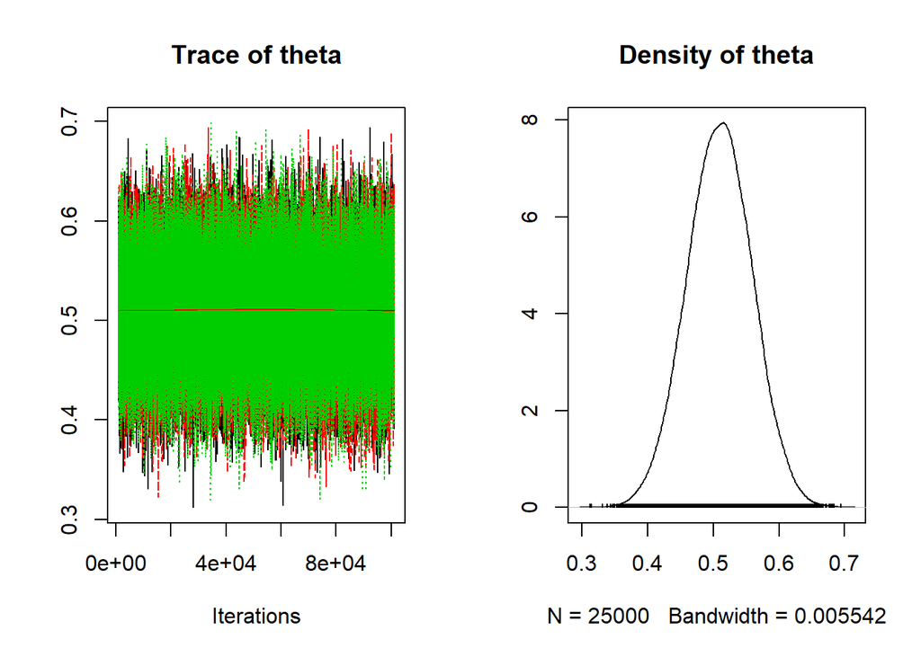

```r
plot(samps)
```

# Linear regression with the Iris data

```r
# Prepare the iris data in a list
data <- list(pw=iris$Petal.Width,
             pl=iris$Petal.Length,
             n=nrow(iris))
```

## The model:

```r
mod <-"
model{

# For each observation in 1:n
  for (i in 1:n){

  # Likelihood of the data

     pw[i] ~ dnorm(mu[i], tau)


  # Regression equation

     mu[i] <-  B0 + B1*pl[i]

  # Calculate residuals 'by hand'
     resid[i] <-  mu[i] - pw[i]
  }


  # Priors

        # Intercept
        B0 ~ dnorm(0, 1/1000)

        # Slope
        B1 ~ dnorm(0, 1/1000)

    # Residual standard deviation
        resid.sd ~ dgamma(0.001, 0.001)

    # Transform sd to precision (JAGS uses precision instead of variance in normal distribution)
        tau <- 1 / resid.sd^2

}
"
```

We’ll use runjags with parallel chains for this example.

```r
# Run the model
results <- run.jags(model=mod,
              data=data,
              n.chains=3,
              adapt=1000,
              burnin=5000,
              monitor=c("B0", "B1", "resid.sd"),
              sample=10000,
              thin=5,
              method="rjparallel")
```

```
## Compiling rjags model...
## Starting 3 rjags simulations using a PSOCK cluster with 3 nodes on
## host 'localhost'
## Simulation complete
## Calculating summary statistics...
## Calculating the Gelman-Rubin statistic for 3 variables....
## Finished running the simulation
```

```r
# Check out summary of model run
summary(results)
```

```
##             Lower95     Median    Upper95       Mean          SD Mode
## B0       -0.4394011 -0.3626526 -0.2827459 -0.3628684 0.039798245   NA
## B1        0.3969008  0.4157013  0.4345069  0.4157185 0.009566207   NA
## resid.sd  0.1848111  0.2067731  0.2321202  0.2074124 0.012201608   NA
##                 MCerr MC%ofSD SSeff        AC.50     psrf
## B0       3.440170e-04     0.9 13383 0.0082398970 1.000164
## B1       8.107429e-05     0.8 13922 0.0078724529 1.000162
## resid.sd 7.044602e-05     0.6 30000 0.0008745913 1.000069
```

**Check for convergence**

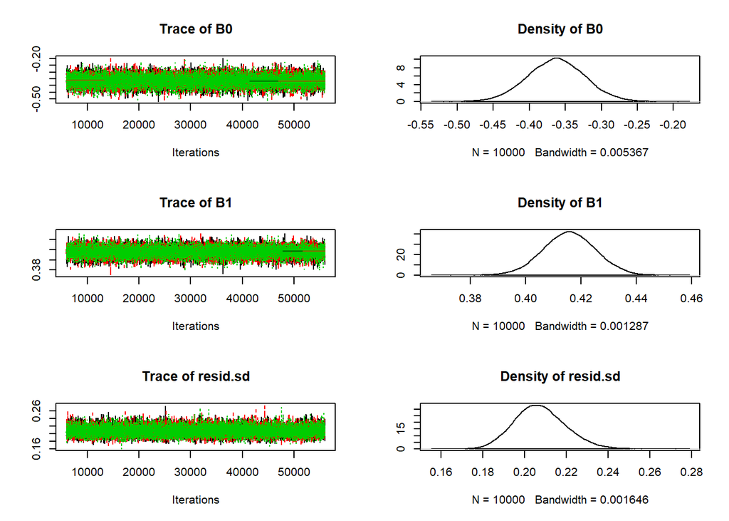

```r
results$mcmc %>% plot()
```

**Look for autocorrelation in samples**

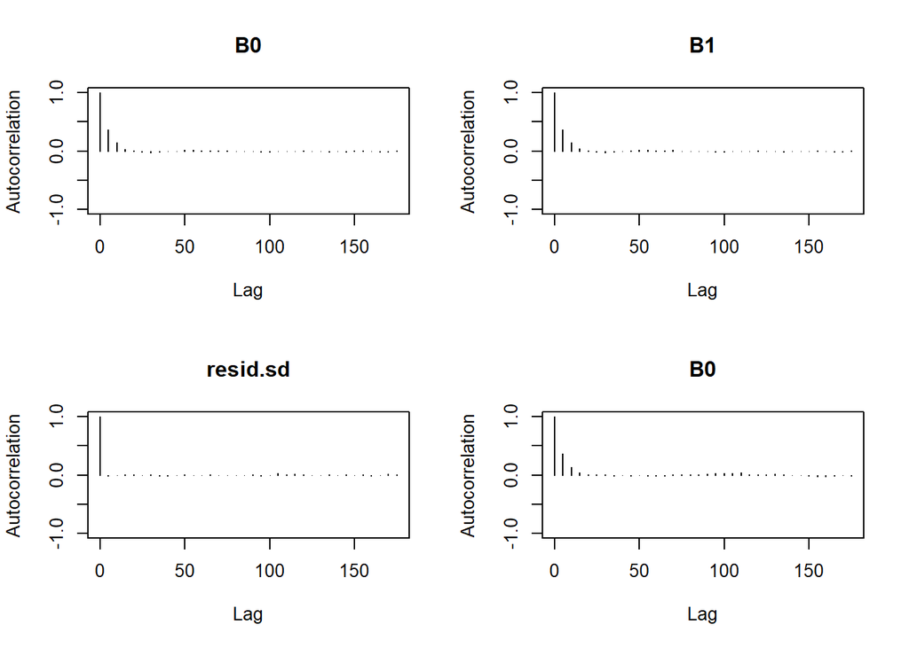

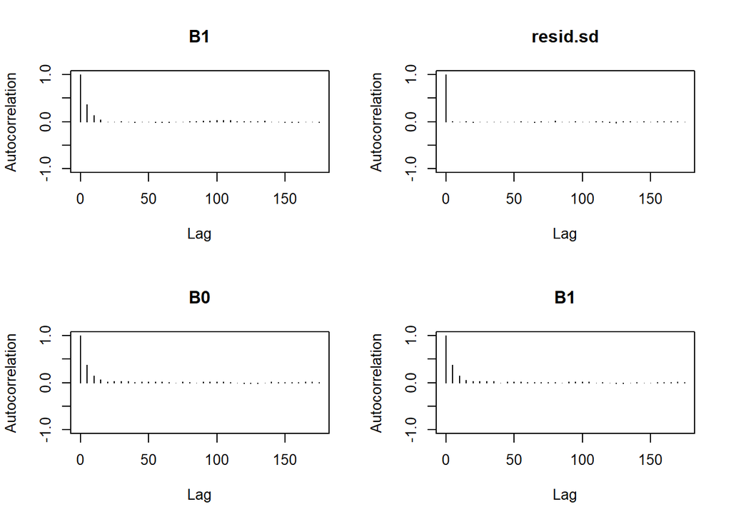

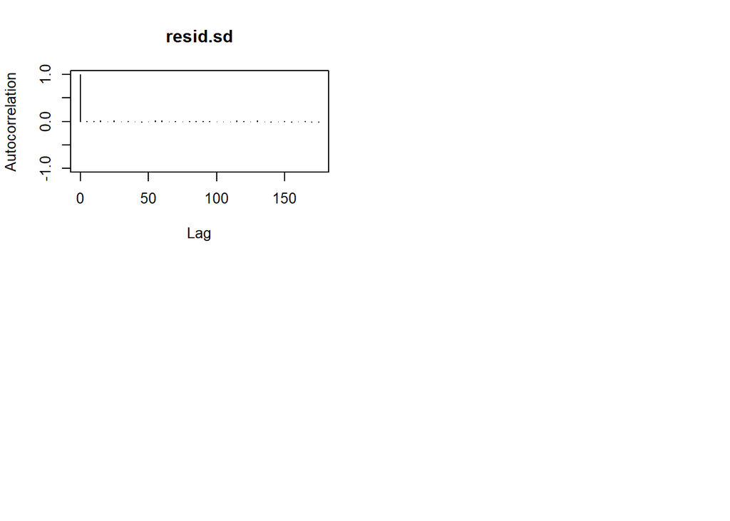

```r
# Look for autocorrelation in chains
results$mcmc %>% autocorr.plot()
```

## **Compare to classical lm**

```r
# MLE fit
m <- lm(Petal.Width ~ Petal.Length, data=iris) %>% summary

# We get the same answer
bayes <- summary(results$mcmc)[[1]][,1:2]

MLE <- rbind(Coefs=m$coefficients[,1:2], Resid.sd=c(m$sigma, NA))

print(list(Bayesian=bayes, Classical=MLE))
```

```
## $Bayesian
##                Mean          SD
## B0       -0.3628684 0.039798245
## B1        0.4157185 0.009566207
## resid.sd  0.2074124 0.012201608
##
## $Classical
##                Estimate  Std. Error
## (Intercept)  -0.3630755 0.039761990
## Petal.Length  0.4157554 0.009582436
## Resid.sd      0.2064843          NA
```